# How Much Arsenic is Too Much? An Exploratory Analysis on Wells in Bangladesh

Austin Phillips

2023-12-08

### Introduction

What seems logical to a doctor in America may be unthinkable to a carpenter in Bangladesh. While the dangers of heavy metal poisoning are well known in the western world, this invisible danger may not be perceived as the grave threat that it is to many of the less economically fortunate. In this exploratory analysis, we are going to look at the data collected from the 2007 Gelman and Hill study on Bangladesh well water. This information not only can be useful for health professionals and volunteers, but for those who study risk-management and the psychology of perceived risk.

In this study, we will be using a logistic regression model to understand why or why not someone would switch wells. This is the most useful model because the act of switching wells is a binary response, and a logistic regression model makes the most sense in this case. The 5 parameters we will be using are: Z(i,1), Which is simply 1 as is necessary when using a logistic regression model. Z(i,2), Which will refer to the arsenic level in the household’s well. Z(i,3), Which is the distance to the nearest known safe well. Z(i,4), Which is a binary variable indicated if a member of the household is involved in any community organizations. Z(i,5), Which is the number of years of education for the most educated member of the household.

The logistic regression model is then
$$\begin{align*}
Y_i \vert z_i &\sim \text{Bernoulli}(\pi_i) \\
\pi_i &= \frac{1}{1 + e^{-z_i^\top\beta}} =
\frac{e^{z_i^\top\beta}}{1 + e^{z_i^\top\beta}}
\end{align*}$$
for each $i = 1, .., n$ and an unknown parameter vector $\beta = (\beta_1, ..., \beta_5)^\top$ of regression coefficients.

This model will answer a few questions - What causes the people of Bangladesh switch wells? Which factors are most important in making this decision? What factors are negligable in this decision?

### Exploratory Analysis

Before we begin we need to analyze our data. This is good practice prior to manipulating it as we can get a good grasp on what we’re working with, and can detect anything obvious that may skew our data or change our approach.

```r
wells <- read.table(file=url("https://michaeljauch.github.io/STA4102Data/wells.txt"), sep=" ", header=TRUE)
n <- nrow(wells)
y <- wells[,c("switch")]
ones <- rep(1, n)
Z <- as.matrix(cbind(ones, wells[, c("arsenic", "dist", "assoc","educ")]))

summary(wells)
```

```
##      switch          arsenic           dist             assoc
##  Min.   :0.0000   Min.   :0.510   Min.   :  0.387   Min.   :0.0000
##  1st Qu.:0.0000   1st Qu.:0.820   1st Qu.: 21.117   1st Qu.:0.0000
##  Median :1.0000   Median :1.300   Median : 36.761   Median :0.0000
##  Mean   :0.5752   Mean   :1.657   Mean   : 48.332   Mean   :0.4228
##  3rd Qu.:1.0000   3rd Qu.:2.200   3rd Qu.: 64.041   3rd Qu.:1.0000
##  Max.   :1.0000   Max.   :9.650   Max.   :339.531   Max.   :1.0000
##       educ
##  Min.   : 0.000
##  1st Qu.: 0.000
##  Median : 5.000
##  Mean   : 4.828
##  3rd Qu.: 8.000
##  Max.   :17.000
```

This summary gives us some baseline information on the data set. Overall, 57% of Bangladeshians did switch from their household well. We can also see that the median amount of arsenic was 1.3 $\mu$l/g. Also to note that the minimum amount of arsenic in the water was 0.5 $\mu$l/g, meaning everyone tested had some amount of arsenic in the water. The median distance to the nearest safe well was 36 meters, which is a reasonable distance if a switch is necessitated. Also to note, 42% of households had a member that was associated in the community. The education gives us some important information, as the bottom 25% of people tested had no education whatsoever, and the top 25% had 8 years of education or more. This shows us that the data in this section is spread out and we will expect to see a lot of people on the tail ends of the histogram, rather then the middle.

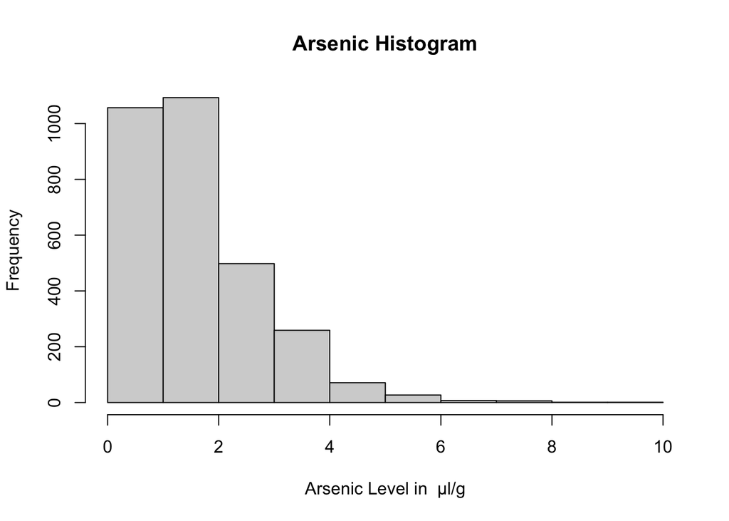

```r
hist(wells$arsenic, main="Arsenic Histogram", xlab="Arsenic Level in  μl/g")
```

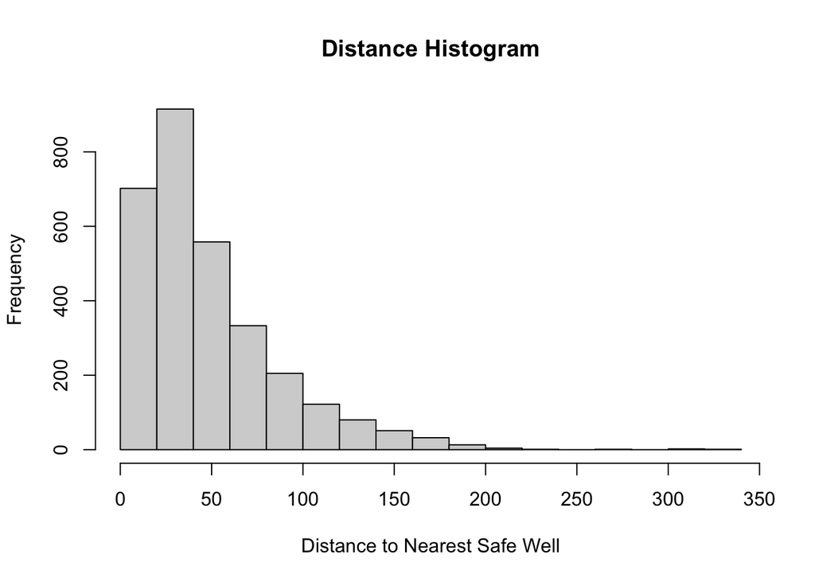

```r
hist(wells$dist, main="Distance Histogram", xlab="Distance to Nearest Safe Well")
```

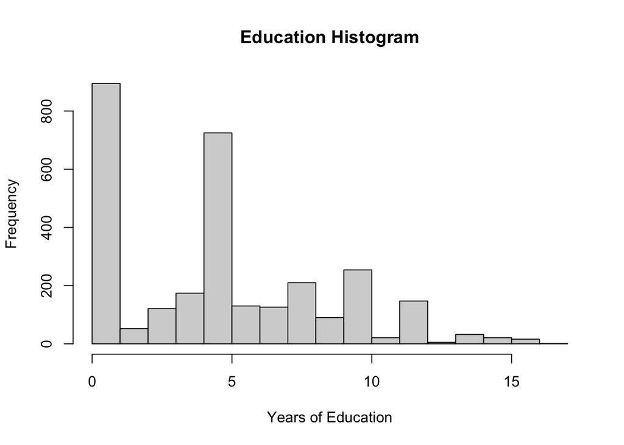

```r
hist(wells$educ, main="Education Histogram", xlab="Years of Education")
```

Looking at the histogram of arsenic, we can see that it appears to take the form of a exponential decay, with the two biggest bins being from 0 to 1, and from 1 to 2. We also see a similar trend with the nearest safe well, with the first 3 bins taking up a majority of the data points. Finally, we see the education which appears to be distributed in a random fashion, where 0 to 1 and 4 to 5 have a large majority of the data points and the rest being someone evenly scattered around from 0-12. After 12 years there does appear to be a significant drop off.

### Data Manipulation

```r
#########################################################################
### NEWTON'S METHOD (LOGISTIC REGRESSION)
#########################################################################

#########################################################################
# x = initial value of the regression coefficients
# itr = number of iterations to run
# x.values = contains values of x for each iteration
# g = objective function
# g.prime = first derivative of objective function
# g.2prime = second derivative of objective function
#########################################################################

#########################################################################

## INITIAL VALUES
x = c(0, 0, 0, 0,0)
itr = 10
x.values = matrix(0,itr+1,5)
x.values[1,] = x

## OBJECTIVE FUNCTION AND DERIVATIVES
g = function(beta, y, Z){
  n <- length(y) # Create a variable n = # of observations
  ones <- rep(1, n) # Create a length n vector of ones
  # Create the b vector
  b <- rep(0, n) # Initial b as a vector of zeros.
  for(i in 1:n){
    b[i] <- log(1 + exp(Z[i,] %*% beta))
  }
  # Calculate and return the log likelihood
  return(y %*% Z %*% beta - b %*% ones)
}

g.prime = function(beta, y, Z){
  n <- length(y) # Create a variable n = # of observations
  # Create the pi vector
  pi_vec <- rep(0, n) # Initial pi_vec as a vector of zeros.
  for(i in 1:n){
    pi_vec[i] <- 1/(1 + exp(-Z[i,] %*% beta))
  }
  # Calculate and return the gradient of the log likelihood
  return(t(Z) %*% (y - pi_vec))
}

g.2prime=function(beta, y, Z){
  n <- length(y) # Create a variable n = # of observations
  # Create pi vector and a vector w of the diagonal elements of W
  pi_vec <- rep(0, n) # Initial pi_vec as a vector of zeros.
  w <- rep(0, n) # Initial w as a vector of zeros.
  for(i in 1:n){
    pi_vec[i] <- 1/(1 + exp(-Z[i,] %*% beta))
    w[i] <- pi_vec[i]*(1-pi_vec[i])
  }
  # Calculate and return the Hessian of the log likelihood
  return(-t(Z) %*% diag(w) %*% Z)
}

## MAIN
for(i in 1:itr){
  x = x - solve(g.2prime(x, y, Z))%*%g.prime(x, y, Z)
  x.values[i+1,] = x
}

## OUTPUT
x       # FINAL ESTIMATE
```

```
##                 [,1]
## ones    -0.156711657
## arsenic  0.467021588
## dist    -0.008961102
## assoc   -0.124299982
## educ     0.042446614
```

```r
x.values
```

```
##              [,1]      [,2]         [,3]       [,4]       [,5]
##  [1,]  0.00000000 0.0000000  0.000000000  0.0000000 0.00000000
##  [2,] -0.08292061 0.3801041 -0.007907759 -0.1149084 0.03822372
##  [3,] -0.15256787 0.4621707 -0.008910053 -0.1239865 0.04228893
##  [4,] -0.15669849 0.4670060 -0.008960949 -0.1242992 0.04244621
##  [5,] -0.15671166 0.4670216 -0.008961102 -0.1243000 0.04244661
##  [6,] -0.15671166 0.4670216 -0.008961102 -0.1243000 0.04244661
##  [7,] -0.15671166 0.4670216 -0.008961102 -0.1243000 0.04244661
##  [8,] -0.15671166 0.4670216 -0.008961102 -0.1243000 0.04244661
##  [9,] -0.15671166 0.4670216 -0.008961102 -0.1243000 0.04244661
## [10,] -0.15671166 0.4670216 -0.008961102 -0.1243000 0.04244661
## [11,] -0.15671166 0.4670216 -0.008961102 -0.1243000 0.04244661
```

Looking at the x values, we can see that this data set converges on the values quite quickly, as after 5 iterations all the values are unchanged.

```r
#test
logreg <- glm(switch ~ arsenic + dist + assoc + educ, data = wells, family = "binomial")
logreg
```

```
##
## Call:  glm(formula = switch ~ arsenic + dist + assoc + educ, family = "binomial",
##     data = wells)
##
## Coefficients:
## (Intercept)      arsenic         dist        assoc         educ
##   -0.156712     0.467022    -0.008961    -0.124300     0.042447
##
## Degrees of Freedom: 3019 Total (i.e. Null);  3015 Residual
## Null Deviance:       4118
## Residual Deviance: 3908  AIC: 3918
```

```r
gamma1prd <- -0.15671
gamma2prd <- 0.46702
gamma3prd <- -0.00896
gamma4prd <- -0.12430
gamma5prd <- 0.04244

gamma1act <- -0.156712
gamma2act <- 0.467022
gamma3act <- -0.008961
gamma4act <- -0.124300
gamma5act <- 0.042447


dif <- c(gamma1act, gamma2act, gamma3act, gamma4act, gamma5act) - c(gamma1prd, gamma2prd, gamma3prd, gamma4prd, gamma5prd)
dif
```

```
## [1] -2e-06  2e-06 -1e-06  0e+00  7e-06
```

### Interpretation

Let’s look at some graphs to help visualize the logistic regression model:

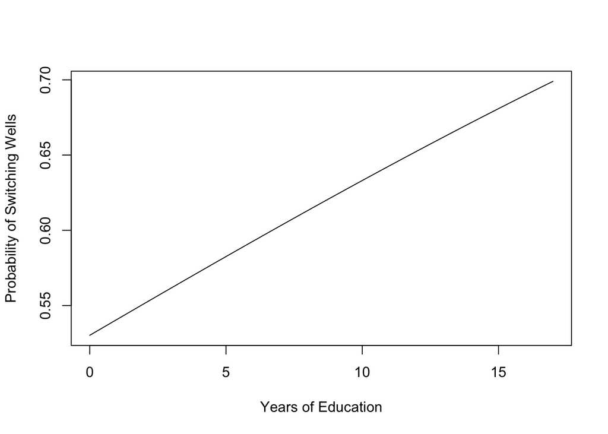

```r
zgrid <- seq(0, 17, length.out=1000)
z2med <- median(Z[,2])
z3med <- median(Z[,3])
z4med <- median(Z[,4])
plot(x=zgrid, y=1/(1 + exp(-1*x[1] - z2med*x[2] - z3med*x[3] - z4med*x[4] - zgrid*x[5])), type="l", ylab="Probability of Switching Wells", xlab="Years of Education" )
```

This graph shows how the years of education affect a household’s likelihood to switch homes (while accounting for other variables). As expected, the more educated someone is the more likely they are want to switch.

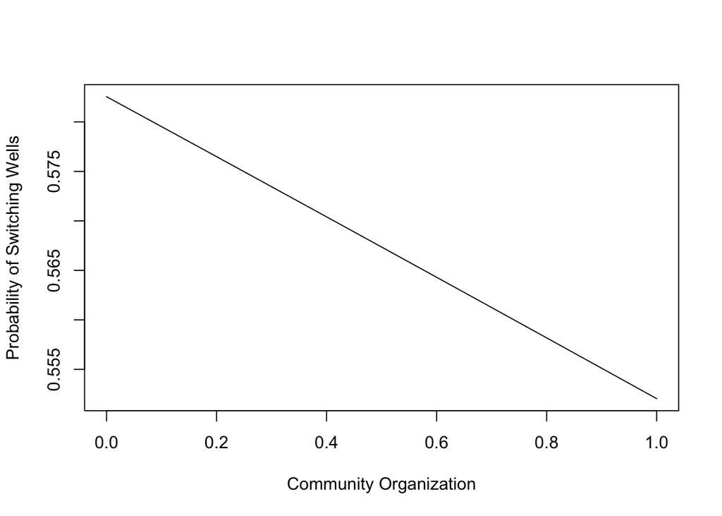

```r
zgrid <- seq(0, 1, length.out=1000)
z2med <- median(Z[,2])
z3med <- median(Z[,3])
z5med <- median(Z[,5])
plot(x=zgrid, y=1/(1 + exp(-1*x[1] - z2med*x[2] - z3med*x[3] - z5med*x[5] - zgrid*x[4])), type="l", ylab="Probability of Switching Wells", xlab="Community Organization" )
```

This graph shows how whether someone is in a community organization or not effects the likelihood of them switching wells. Since this is a binary indicator, the only part of this graph that should be noted is the 0 or 1 on the x axis. Overall, this indicator seemed to have no impact on whether a household switched wells.

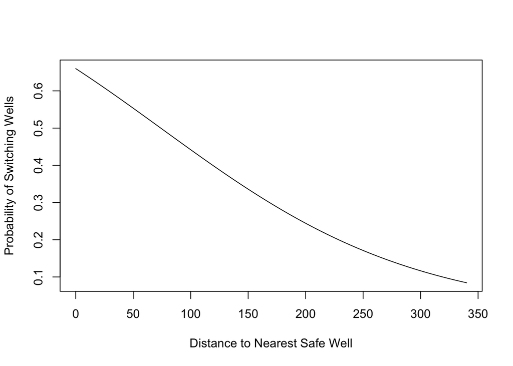

```r
zgrid <- seq(0, 340, length.out=1000)
z2med <- median(Z[,2])
z4med <- median(Z[,4])
z5med <- median(Z[,5])
plot(x=zgrid, y=1/(1 + exp(-1*x[1] - z2med*x[2] - z4med*x[4] - z5med*x[5] - zgrid*x[3])), type="l", ylab="Probability of Switching Wells", xlab="Distance to Nearest Safe Well" )
```

This graph shows the true impact of distance on whether a family will switch or not. Although the logarithmic regression model give this indicator only a -.009, that does not take into account the scale of this indicator. In our maximum distance, which was 340 meters, the likelihood that they switch wells is 10%, where as a family that is only 50 meters away from a well has a 55% chance of switching wells.

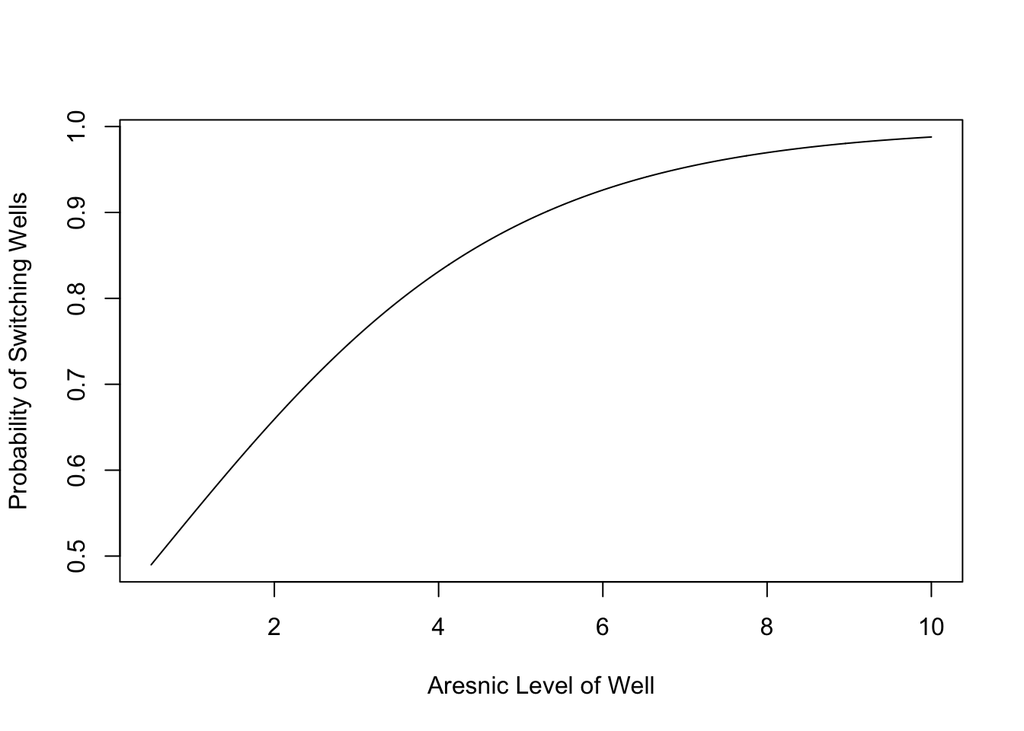

```r
zgrid <- seq(0.5, 10, length.out=1000)
z3med <- median(Z[,3])
z4med <- median(Z[,4])
z5med <- median(Z[,5])
plot(x=zgrid, y=1/(1 + exp(-1*x[1] - z3med*x[3] - z4med*x[4] - z5med*x[5] - zgrid*x[2])), type="l", ylab="Probability of Switching Wells", xlab="Aresnic Level of Well" )
```

Arsenic level also has a major impact on a households decision making. A family with the minimum amount of arsenic tested (0.5 $\mu$l/g) in their well has about a 50% chance to switch wells, However once that level hits 8 $\mu$l/g, it is almost guaranteed that the family will switch wells.

### Conclusion

While the idea of switching wells that are poisoned with arsenic may seem like an obvious choice, there are many factors that come into play. In this exploratory study, We determined that the two most important factors for a family when deciding to change wells has to do with the amount of arsenic in the well and the distance to the closest safe well. This conclusion reinforces the disposition we may have had going into the study. Education level also had a slight role in influencing the decision making process, which one again seems intuitive. The one factor that did not play a significant role was community involvement. Although we can not be certain that it has no effect on a households decision, when compared to the other factors tested it appeared negligible in our tests. We cannot say if these are the only factors at play as there were many more that weren’t tested (size of the family, household income, etc). As an exploratory analysis, our conclusions are limited to the scope of correlations, and not causational relationships. Without actual testing, it is impossible to say what would happen if some of these factors were mitigated and/or exacerbated, however, it provides an initial overview on the issue at hand, and can be a stepping stone for future testing and aid.